# Final Project - OneTwoTrip

### Load the dataset

```python
df = pd.read_csv('onetwotrip_challenge_train.csv')
df_train = df.copy()
```

```python
X.head()
```

|  | orderid | userid | field0 | field1 | field2 | field3 | field4 | field5 | field6 | field7 | ... | indicator_goal21 | indicator_goal22 | indicator_goal23 | indicator_goal24 | indicator_goal25 | goal21 | goal22 | goal23 | goal24 | goal25 |
| --- | --- | --- | --- | --- | --- | --- | --- | --- | --- | --- | --- | --- | --- | --- | --- | --- | --- | --- | --- | --- | --- |
| 0 | 0 | 10d654494cbe97bbb25d51ead2600679aff9e097924add... | 0 | -0.626508 | 11 | 12 | 1 | 1 | 0 | 1 | ... | 1 | 1 | 0 | 1 | 1 | 0 | 1 | 0 | 0 | 0 |
| 1 | 1 | 4aafc0391f72bbcf60537aece62923baf9ce644b64ac36... | 144 | -0.393794 | 5 | 7 | 2 | 0 | 0 | 2 | ... | 1 | 1 | 0 | 1 | 0 | 0 | 0 | 0 | 0 | 0 |
| 2 | 2 | bac8ffef46348f587c8d17137ab01fb24aef21547c647d... | 134 | -0.548937 | 2 | 3 | 2 | 0 | 0 | 1 | ... | 1 | 1 | 0 | 1 | 1 | 0 | 0 | 0 | 0 | 0 |
| 3 | 3 | 0392247b4b87674aba2c32bf2292b105771a6a376871be... | 0 | -0.238651 | 10 | 11 | 1 | 1 | 3 | 2 | ... | 1 | 1 | 0 | 1 | 1 | 0 | 0 | 0 | 0 | 0 |
| 4 | 4 | d1aeefef311bbeb4bd84876c8d49421f276674527d5578... | 0 | -0.704079 | 8 | 11 | 1 | 1 | 0 | 1 | ... | 1 | 1 | 0 | 0 | 1 | 0 | 0 | 0 | 0 | 0 |

5 rows × 42 columns

```python
print(f'Number of features {X.shape[1]}')
print(f'Number of examples in the data set {X.shape[0]}')
```

```
Number of features 42
Number of examples in the data set 196056
```

### Train-test split. We split in a stratified way because classes are highly unbalanced.

```python
y.value_counts()
```

```
0    191715
1      4341
Name: goal1, dtype: int64
```

```python
X_train, X_test, y_train, y_test = train_test_split(X,
                                                    y,
                                                    test_size=0.25,
                                                    random_state=42,
                                                   stratify = y)
```

### There is no missing variables

```python
X_train.isna().sum().sum()
```

```
0
```

```python
X_test.isna().sum().sum()
```

```
0
```

### Heat map, which shows correlations between all features

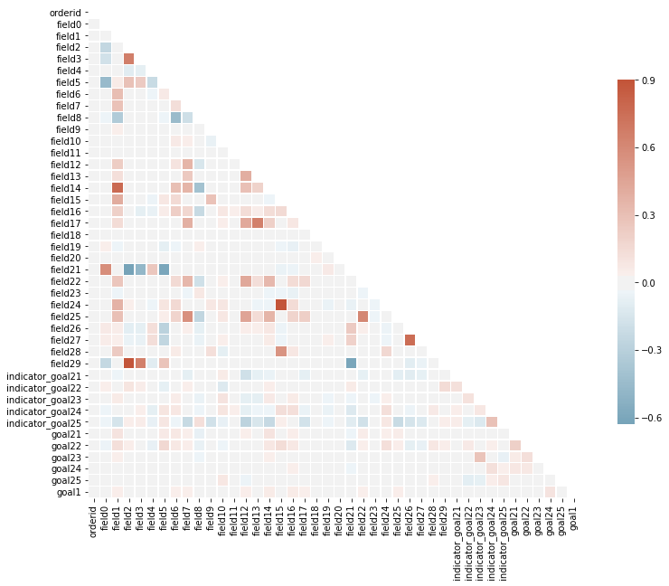

```python
corr = df_train.corr()
mask = np.triu(np.ones_like(corr, dtype=bool))
f, ax = plt.subplots(figsize=(15, 10))
cmap = sns.diverging_palette(230, 20, as_cmap=True)
sns.heatmap(corr, mask=mask, cmap=cmap, vmax=.9, center=0,
            square=True, linewidths=.5, cbar_kws={"shrink": .7})
```

### We can see that some features of the input correlate with each other. We will build scatter plots for them and see what we can learn from it.

### Let's look at Field2 and Field3

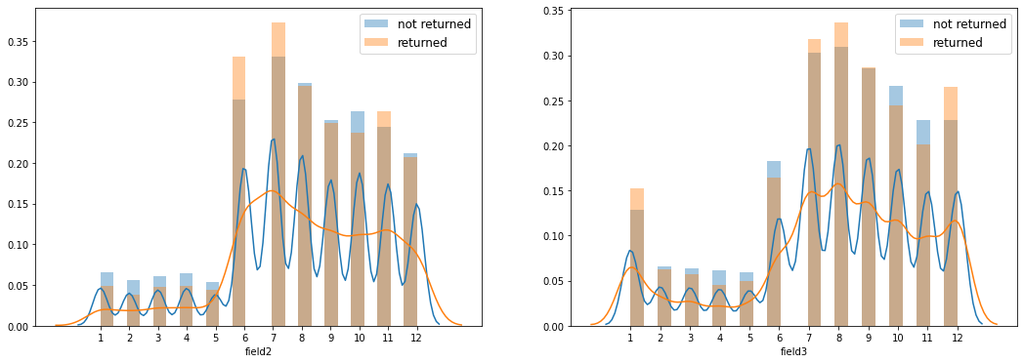

```python
fig, axes = plt.subplots(nrows=1, ncols=2, figsize=(18, 6))
plt.rc('font', **{'size':12})

sns.distplot(df_train[df_train['goal1'] == 0]['field2'], bins=24, label='not returned', norm_hist=True, ax = axes[0])
sns.distplot(df_train[df_train['goal1'] == 1]['field2'], bins=24, label='returned', norm_hist=True, ax = axes[0])
axes[0].set_xticks(range(1,13))
axes[0].legend()

sns.distplot(df_train[df_train['goal1'] == 0]['field3'], bins=24, label='not returned', norm_hist=True, ax = axes[1])
sns.distplot(df_train[df_train['goal1'] == 1]['field3'], bins=24, label='returned', norm_hist=True, ax = axes[1])
axes[1].set_xticks(range(1,13))
axes[1].legend()

plt.show()
```

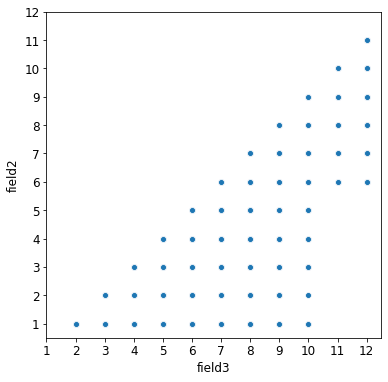

```python
plt.figure(figsize=(6,6))
plt.rc('font', **{'size':12})

sns.scatterplot(df_train.field3, df_train.field2[df_train.field2<df_train.field3])
plt.xticks(range(1,13))
plt.yticks(range(1,13))
plt.show()
```

### Let's look at Field29 and Field21

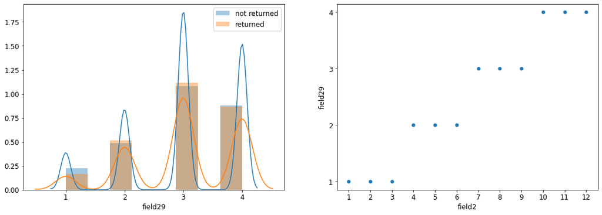

```python
fig, axes = plt.subplots(nrows=1, ncols=2, figsize=(18, 6))
plt.rc('font', **{'size':12})

sns.distplot(df_train[df_train['goal1'] == 0]['field29'], bins=8, label='not returned', norm_hist=True, ax = axes[0])
sns.distplot(df_train[df_train['goal1'] == 1]['field29'], bins=8, label='returned', norm_hist=True, ax = axes[0])
axes[0].set_xticks(range(1,5))
axes[0].legend()

sns.scatterplot(df_train.field2, df_train.field29, s = 50, ax = axes[1])
axes[1].set_xticks(range(1,13))
axes[1].set_yticks(range(1,5))

plt.show()
```

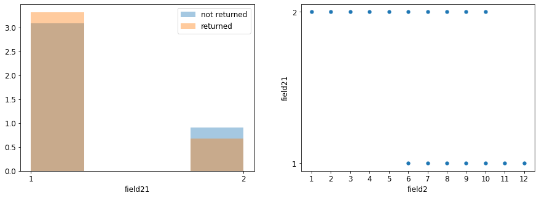

```python
fig, axes = plt.subplots(nrows=1, ncols=2, figsize=(15, 5))
plt.rc('font', **{'size':12})

sns.distplot(df_train[df_train['goal1'] == 0]['field21'], kde = False, bins=4, label='not returned', norm_hist=True, ax = axes[0])
sns.distplot(df_train[df_train['goal1'] == 1]['field21'], kde = False, bins=4, label='returned', norm_hist=True, ax = axes[0])
axes[0].set_xticks(range(1,3))
axes[0].legend()

sns.scatterplot(df_train.field2, df_train.field21, s = 50, ax = axes[1])
axes[1].set_xticks(range(1,13))
axes[1].set_yticks(range(1,3))

plt.show()
```

- Field21 - year
- Field29 - season

### Lets' look at Field9, Field24, Field28 and Field15

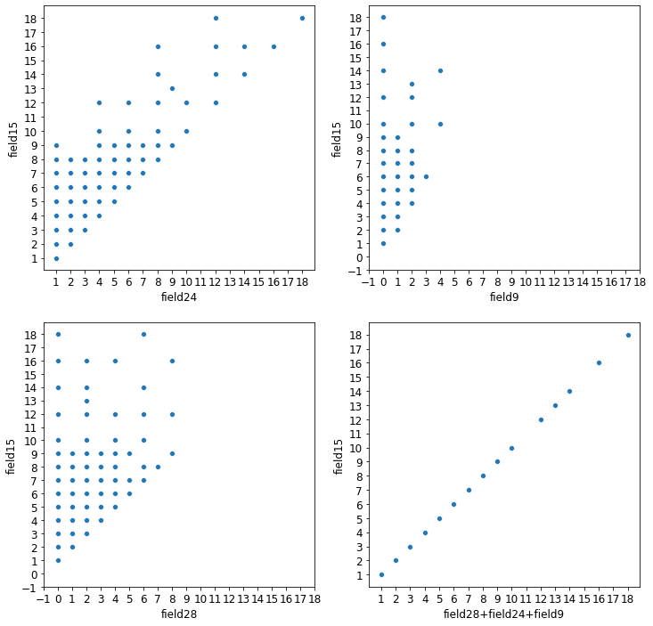

```python
for_pretty_presentation()
```

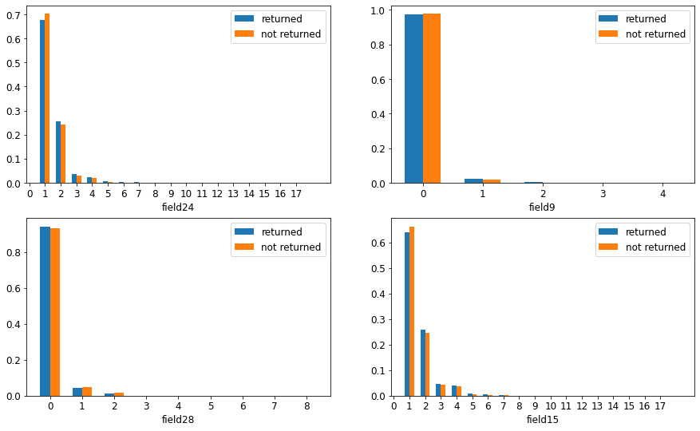

```python
plot(['field24', 'field9', 'field28', 'field15'])
```

- Features 9, 24, and 28 are the numbers of different class tickets in the purchase and feature 15 is the number of all bought tickets.
- Since they are linearly dependent we can drop one of them. According to bar plots, the most uninformative features are 9 and 28, so we removed feature 28.
- We can see that majority of the values in field15 and field24 are less than 5. Therefore we put all the rest in one class.
- We can see that majority of the values in field9 are zeros. So we created a new feature - is_zero

### Let's look at Field23 and Field11

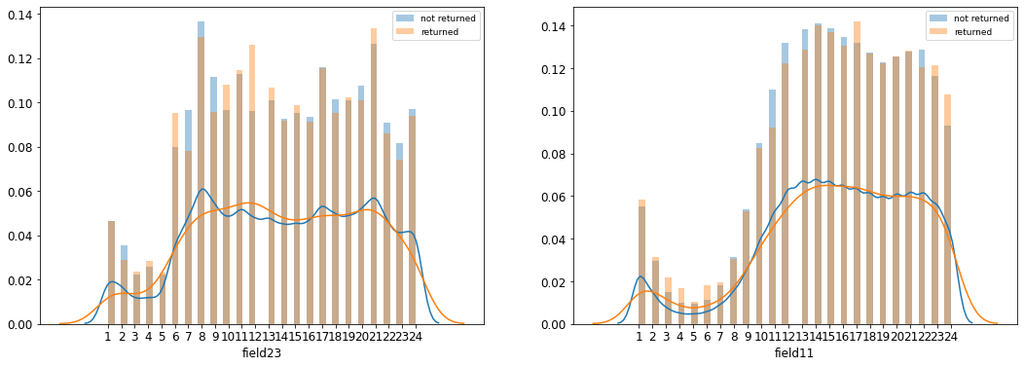

```python
fig, axes = plt.subplots(nrows=1, ncols=2, figsize=(18, 6))
plt.rc('font', **{'size':9})

sns.distplot(df_train[df_train['goal1'] == 0]['field23'].apply(lambda x: x+1), bins=48, label='not returned', norm_hist=True, ax = axes[0])
sns.distplot(df_train[df_train['goal1'] == 1]['field23'].apply(lambda x: x+1), bins=48, label='returned', norm_hist=True, ax = axes[0])
axes[0].set_xticks(range(1,25))
axes[0].legend()

sns.distplot(df_train[df_train['goal1'] == 0]['field11'].apply(lambda x: x+1), bins=48, label='not returned', norm_hist=True, ax = axes[1])
sns.distplot(df_train[df_train['goal1'] == 1]['field11'].apply(lambda x: x+1), bins=48, label='returned', norm_hist=True, ax = axes[1])
axes[1].set_xticks(range(1,25))
axes[1].legend()

plt.show()
```

- Field23 and Field11 are hours of departure and ticket purchase

### Let's look at Field18 and Field 20

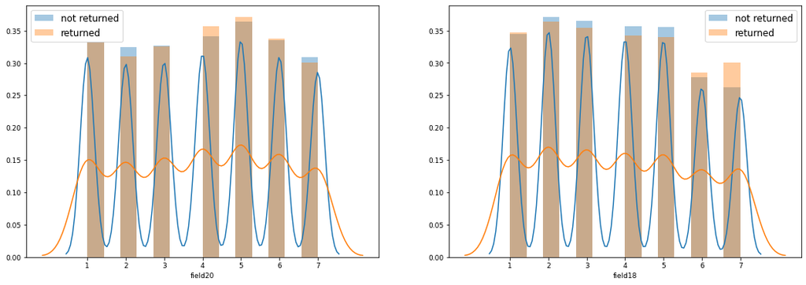

```python
fig, axes = plt.subplots(nrows=1, ncols=2, figsize=(18, 6))
plt.rc('font', **{'size':12})
sns.distplot(df_train[df_train['goal1'] == 0]['field20'], bins=14, label='not returned', norm_hist=True, ax = axes[0])
sns.distplot(df_train[df_train['goal1'] == 1]['field20'], bins=14, label='returned', norm_hist=True, ax = axes[0])
axes[0].set_xticks(range(1,8))
axes[0].legend()
sns.distplot(df_train[df_train['goal1'] == 0]['field18'], bins=14, label='not returned', norm_hist=True, ax = axes[1])
sns.distplot(df_train[df_train['goal1'] == 1]['field18'], bins=14, label='returned', norm_hist=True, ax = axes[1])
axes[1].set_xticks(range(1,8))
axes[1].legend()
plt.show()
```

- Field18 and Field20 are probably week days of departure and ticket purchase
- From graph on the right we can see that more tickets were returned during the weekend, so we decided to create a new feature - is_weekend.
- From graph on the left we can see the same situation with Thursday, Friday and Saturday, so we decided to create a new feature - is_these_days

### Let's look at Field16

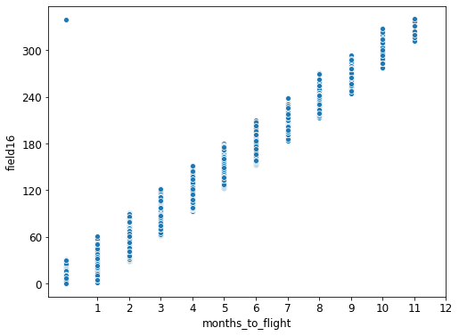

```python
plt.figure(figsize=(8,6))
plt.rc('font', **{'size':12})

df_train['months_to_flight'] = (df_train['field3'] - df_train['field2']).apply(lambda x: x if x >= 0 else x + 12)
sns.scatterplot(df_train.months_to_flight, df_train.field16)
plt.xticks(range(1,13))
plt.yticks(range(0, 360, 60))
plt.show()
```

- Field16 - the number of days to the flight. It seems very important.

### Let's preprocess our data

```python
features_to_drop = ["field0", "field4", "field6", "field12",
                            "field13","field17","field19","field22","field25",
                            "field26","field27","field28","indicator_goal21",
                            "indicator_goal22","indicator_goal23",
                            "goal23","goal25"]
float_features = ['field1', 'field14', 'number_of_tickets_to_date','field16']
cat_features = ['field2', 'field3', 'field11',
                        'field23', 'field15', 'field24', 'field29']
```

### Examples of useless features

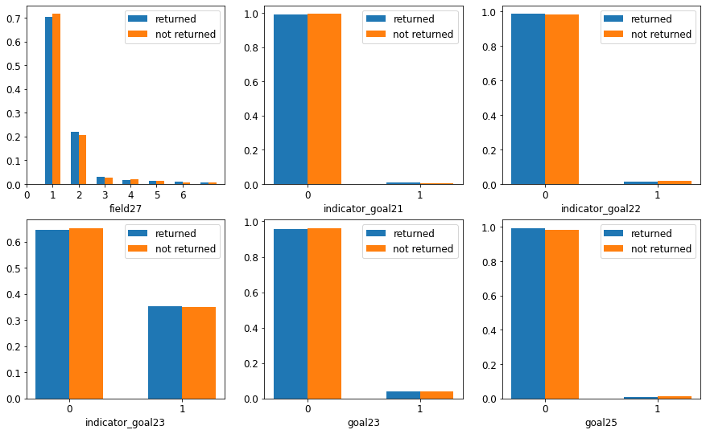

```python
plot(["field27","indicator_goal21",
                                  "indicator_goal22","indicator_goal23",
                                  "goal23","goal25"], 3)
```

### More features generation

```python
number_of_tickets_to_date = X_train.sort_values(['field21','field2']).groupby('userid')['field15'].cumsum()
```

### Preprocessing data

```python
prep = Preprocesser()
prep.fit(X_train)

X_train_ = prep.transform(X_train)
X_test_ = prep.transform(X_test)
```

### Unbalanced train set

```python
y_train.value_counts()/y_train.value_counts().sum()
```

```
0    0.977857
1    0.022143
Name: goal1, dtype: float64
```

### Best model parameters selection

```python
#select the params for xgboost
cv = StratifiedKFold(n_splits=3, shuffle=True, random_state=7)
clf = XGBClassifier(reg_alpha=1, max_depth=4)

grid = {
    'n_estimators': range(500, 1100, 100),
    'learning_rate': [10**(-2), 5*10**(-3)],
    'reg_lambda': [1,3,5]
}
xgb_gs = GridSearchCV(clf, param_grid=grid, cv=cv, n_jobs = 8, scoring='roc_auc')
params = {'eval_metric': 'auc'}
start_time = time.time()
xgb_gs.fit(X_train_, y_train, **params)
print("--- %s seconds ---" % (time.time() - start_time))
```

```
--- 30832.645278930664 seconds ---
```

```python
xgb_gs.best_params_
```

```
{'learning_rate': 0.01, 'n_estimators': 800, 'reg_lambda': 5}
```

### Results

```python
# comment to create pretty pdf
# best = xgb_gs.best_estimator_
# best.fit(X_train_, y_train, eval_metric='auc', verbose=True, eval_set=[(X_train_, y_train)])
```

```python
from sklearn.metrics import roc_auc_score

pred = best.predict_proba(X_test_)[:, 1]
pred_train = best.predict_proba(X_train_)[:, 1]

print(roc_auc_score(y_train, pred_train), roc_auc_score(y_test, pred))
```

```
0.7303702993163024 0.7025584442156326
```

### Conclusions

- Choosing thresholds depending on what is more important
- Save money by taking reasonable precautions
- The model solves the stated problem
- The method can be applied to any unbalanced classification problem

### The most important thing that we learned while working

- Working with anonymized data
- Appropriate metric - key to solve unbalanced class problem

### Additional materials

### Oversampling

```python
pred = up_clf.predict_proba(X_test_)[:, 1]
pred_train = up_clf.predict_proba(X_train_upsampled)[:, 1]

print(roc_auc_score(Y_train_upsampled, pred_train), roc_auc_score(y_test, pred))
```

```
0.7505858206244447 0.6935584442156326
```